# cmp713-project

Hazem Alabiad & Betül Bayrak

25/01/2021

# Introduction

Tipping someone is a common thing in our community, especially if this person is a taxi driver, waiter, or delivery officer; The tip amount varies depending on many conditions; In the case of a taxi driver, it might depend on the passenger count, trip distance, trip hour, et cetera. In this project, we aim to study and predict the tip percentage of the total amount paid to taxi drivers. We used the data provided by NYC Taxi & Limousine Commission (TLC) from this [link](https://www1.nyc.gov/site/tlc/about/tlc-trip-record-data.page). First, we explore our data to know what our data looks like, find potential outliers, obtain general and basic statistics, for instance, observations count, variables count, NAs’ count, et cetera. Second, we apply what is called data pre-processing and data engineering that include removing unnecessary or NAs’ rows, columns, convert the data type to a more suitable one and introducing new variables to get our data ready to be fed our model that is going to predict the tip amount given other variables. Third, we build our models that utilize the pre-processed, clean data to predict a variable “tip percentage in our case”. Lastly, we measure the performance or accuracy of our model using many approaches and mathematical formulas and plot the predictions vs. actual tip percentage to decide on which model did the best.

# Loading Libraries

```r
library(randomForest)
library(ggmap)
library(h2o)
library(gridExtra)
library(dplyr)
```

```r
library(ggplot2)
library(nnet)
library(hrbrthemes)
library(rpart.plot)
library(mlbench)
library(e1071)
library(rpart)
library(DMwR2)
library(caret)
library(Metrics)
library(fpc)
library(Hmisc)
library(tibble)
library(knitr)
library(MLmetrics)
library(earth) # fit MARS models
```

# Custom Functions

```r
`%notin%` <- Negate(`%in%`)

pretty_df_print <- function (df) kable_styling(kable(df))

top_least_freq_and_neg_vals <- function (col) {
  t <- table(col) %>% as.data.frame() %>% arrange(desc(Freq))
  non_pos <- as.data.frame(col)
  non_pos <- non_pos[non_pos <=0, ]
  print("Top frequent values:")
  print.data.frame(head(t))
  print("Least frequent values:")
  print.data.frame(tail(t))
  print("Negative values:")
  print.data.frame(non_pos)
  print("/////////////////////////////////////////////////////")
}

na_count_df <- function (df) {
  return(as.data.frame(t(data.frame(sapply(df, function(col) sum(is.na(col)))))))
}

iqr_outliers_min_max <- function(df) {
  iqr_df <- as.data.frame( t(data.frame(df %>% sapply(function (x) {quantile(x, c(0.25, 0.75))}))) ) %>% cbind((data.frame(df %>% sapply(IQR))))
  colnames(iqr_df) <- c("Q1", "Q3", "IQR")
  iqr_df$minVal <- iqr_df$Q1 - 1.5*iqr_df$IQR
  iqr_df$maxVal <- iqr_df$Q3 + 1.5*iqr_df$IQR
  print.data.frame(iqr_df %>% select("minVal", "maxVal"))
}

iqr_outliers_finder <- function(x){
  Q1 <- quantile(x, 0.25)
  Q3 <- quantile(x, 0.75)
  IQR <- Q3 - Q1
  Vl <- Q1 - 1.5 * IQR
  Vr <- Q3 + 1.5 * IQR
  return (x[which(x < Vl | x > Vr)])
}

get_freq_df_from_vector <- function (vec, col.name) {
  freq_df <- as.data.frame(table(vec))
  colnames(freq_df)[1] <- col.name
  freq_df <- freq_df[order(freq_df[,1], decreasing = T),]
  if(nrow(freq_df) <= 10) {
    print.data.frame(freq_df)}
  else {
    cat("Highest values :\n")
    print.data.frame(head(freq_df))
    cat("Lowest values :\n")
    print.data.frame(tail(freq_df))
  }
}

dbscan_outliers_finder <- function(data, ...) {
  require(fpc, quietly=TRUE)
  cl <- dbscan(data, ...)
  posOuts <- which(cl$cluster == 0)
  list(positions = posOuts,
       outliers = data[posOuts,],
       dbscanResults = cl)
}
```

# Data loading

```r
st <- proc.time()
green <- read.csv("data/green_tripdata_2020-06.csv")
green <- green %>% rbind(read.csv("data/green_tripdata_2020-01.csv"))
print(proc.time() - st)
```

```
##    user  system elapsed
##   5.824   0.157   6.005
```

```r
cat('There are [', nrow(green), '] observations, and [',ncol(green),'] variables')
```

```
## There are [ 510879 ] observations, and [ 20 ] variables
```

# Data exploratory & Preprocessing

## Dataframe head

```r
head(green)
```

```
##   VendorID lpep_pickup_datetime lpep_dropoff_datetime store_and_fwd_flag
## 1        1  2020-06-01 00:22:07   2020-06-01 00:39:03                  N
## 2        2  2020-06-01 00:09:05   2020-06-01 00:22:46                  N
## 3        2  2020-06-01 00:20:05   2020-06-01 00:23:33                  N
## 4        2  2020-06-01 00:30:50   2020-06-01 00:37:49                  N
## 5        2  2020-06-01 00:03:05   2020-06-01 00:16:46                  N
## 6        2  2020-06-01 00:14:05   2020-06-01 00:23:57                  N
##   RatecodeID PULocationID DOLocationID passenger_count trip_distance
## 1          1          255           14               1          0.00
## 2          1          166          141               1          3.43
## 3          1           75           42               1          1.03
## 4          1           74           42               1          1.22
## 5          1          152          247               1          2.59
## 6          1          244          200               1          5.95
##   fare_amount extra mta_tax tip_amount tolls_amount ehail_fee
```

[output cut: 20 more lines]

## Dataframe tail

```r
tail(green)
```

```
##        VendorID lpep_pickup_datetime lpep_dropoff_datetime store_and_fwd_flag
## 510874       NA  2020-01-31 23:08:00   2020-01-31 23:26:00
## 510875       NA  2020-01-31 23:29:00   2020-01-31 23:47:00
## 510876       NA  2020-01-31 23:57:00   2020-02-01 00:23:00
## 510877       NA  2020-01-31 23:57:00   2020-02-01 00:10:00
## 510878       NA  2020-01-31 23:27:00   2020-02-01 00:04:00
## 510879       NA  2020-01-31 23:36:00   2020-02-01 00:01:00
##        RatecodeID PULocationID DOLocationID passenger_count trip_distance
## 510874         NA           14          206              NA          7.51
## 510875         NA          167           32              NA          4.58
## 510876         NA           81           69              NA          6.55
## 510877         NA          244          241              NA          3.34
## 510878         NA           68           17              NA          8.92
## 510879         NA           22          124              NA         13.51
##        fare_amount extra mta_tax tip_amount tolls_amount ehail_fee
```

[output cut: 20 more lines]

## Brief info on the data

```r
str(green)
```

```
## 'data.frame':    510879 obs. of  20 variables:
##  $ VendorID             : int  1 2 2 2 2 2 2 2 2 2 ...
##  $ lpep_pickup_datetime : chr  "2020-06-01 00:22:07" "2020-06-01 00:09:05" "2020-06-01 00:20:05" "2020-06-01 00:30:50" ...
##  $ lpep_dropoff_datetime: chr  "2020-06-01 00:39:03" "2020-06-01 00:22:46" "2020-06-01 00:23:33" "2020-06-01 00:37:49" ...
##  $ store_and_fwd_flag   : chr  "N" "N" "N" "N" ...
##  $ RatecodeID           : int  1 1 1 1 1 1 1 1 1 1 ...
##  $ PULocationID         : int  255 166 75 74 152 244 93 85 82 174 ...
##  $ DOLocationID         : int  14 141 42 42 247 200 95 188 70 127 ...
##  $ passenger_count      : int  1 1 1 1 1 1 1 1 1 1 ...
##  $ trip_distance        : num  0 3.43 1.03 1.22 2.59 5.95 2.25 0.65 3.5 3.38 ...
##  $ fare_amount          : num  28.2 13 5 7 11.5 17.5 11 5 12 11.5 ...
##  $ extra                : num  0 0.5 0.5 0.5 0.5 0.5 0.5 0.5 0.5 0.5 ...
##  $ mta_tax              : num  0.5 0.5 0.5 0.5 0.5 0.5 0.5 0.5 0.5 0.5 ...
##  $ tip_amount           : num  0 3.41 0 0 0 6 0 0 2.66 0 ...
##  $ tolls_amount         : num  0 0 0 0 0 2.8 0 0 0 0 ...
##  $ ehail_fee            : logi  NA NA NA NA NA NA ...
##  $ improvement_surcharge: num  0.3 0.3 0.3 0.3 0.3 0.3 0.3 0.3 0.3 0.3 ...
##  $ total_amount         : num  29 20.5 6.3 8.3 12.8 ...
##  $ payment_type         : int  1 1 2 2 2 1 2 2 1 2 ...
##  $ trip_type            : int  1 1 1 1 1 1 1 1 1 1 ...
##  $ congestion_surcharge : num  0 2.75 0 0 0 0 0 0 0 0 ...
```

## Unnecessary Variables Deletion

```r
num.vars <- ncol(green)
green <- green %>% subset(select = -c( VendorID, store_and_fwd_flag))
cat("[", num.vars - ncol(green) , "] variables were delete")
```

```
## [ 2 ] variables were delete
```

## Summary of the data

```r
describe(green)
```

```
## green
##
##  18  Variables      510879  Observations
## --------------------------------------------------------------------------------
## lpep_pickup_datetime
##        n  missing distinct
##   510879        0   385504
##
## lowest : 2008-12-31 22:06:48 2008-12-31 23:11:00 2009-01-01 00:07:51 2009-01-01 00:08:09 2009-01-01 00:34:50
## highest: 2020-06-30 23:42:13 2020-06-30 23:51:12 2020-06-30 23:52:09 2020-06-30 23:57:39 2020-06-30 23:59:37
## --------------------------------------------------------------------------------
## lpep_dropoff_datetime
##        n  missing distinct
##   510879        0   385627
##
## lowest : 2008-12-31 23:12:08 2009-01-01 00:17:31 2009-01-01 00:45:10 2009-01-01 00:58:27 2009-01-01 01:00:23
## highest: 2020-07-01 10:24:18 2020-07-01 12:00:04 2020-07-01 13:27:36 2020-07-01 14:51:21 2020-07-01 15:59:47
## --------------------------------------------------------------------------------
## RatecodeID
##        n  missing distinct     Info     Mean      Gmd
##   370150   140729        7    0.083    1.107   0.2087
##
## lowest :  1  2  3  4  5, highest:  3  4  5  6 99
##
## Value           1      2      3      4      5      6     99
## Frequency  359569    727    189    269   9390      4      2
## Proportion  0.971  0.002  0.001  0.001  0.025  0.000  0.000
## --------------------------------------------------------------------------------
## PULocationID
##        n  missing distinct     Info     Mean      Gmd      .05      .10
##   510879        0      256    0.999    108.1    78.84       18       33
##      .25      .50      .75      .90      .95
##       52       82      166      226      244
##
## lowest :   1   3   4   5   6, highest: 261 262 263 264 265
## --------------------------------------------------------------------------------
## DOLocationID
##        n  missing distinct     Info     Mean      Gmd      .05      .10
##   510879        0      260        1    128.6    87.77       21       37
##      .25      .50      .75      .90      .95
```

[output cut: 122 more lines]

```
## --------------------------------------------------------------------------------
## congestion_surcharge
##        n  missing distinct     Info     Mean      Gmd
##   370150   140729        5    0.429   0.4751   0.7861
##
## lowest : -2.75  0.00  0.75  2.50  2.75, highest: -2.75  0.00  0.75  2.50  2.75
##
## Value       -2.75   0.00   0.75   2.50   2.75
## Frequency       5 306179      6    163  63797
## Proportion  0.000  0.827  0.000  0.000  0.172
## --------------------------------------------------------------------------------
##
## Variables with all observations missing:
##
## [1] ehail_fee
```

## Count NAs’ in each column

```r
na_count_df(green)
```

```
##                                           lpep_pickup_datetime
## sapply.df..function.col..sum.is.na.col...                    0
##                                           lpep_dropoff_datetime RatecodeID
## sapply.df..function.col..sum.is.na.col...                     0     140729
##                                           PULocationID DOLocationID
## sapply.df..function.col..sum.is.na.col...            0            0
##                                           passenger_count trip_distance
## sapply.df..function.col..sum.is.na.col...          140729             0
##                                           fare_amount extra mta_tax tip_amount
## sapply.df..function.col..sum.is.na.col...           0     0       0          0
##                                           tolls_amount ehail_fee
## sapply.df..function.col..sum.is.na.col...            0    510879
##                                           improvement_surcharge total_amount
## sapply.df..function.col..sum.is.na.col...                     0            0
##                                           payment_type trip_type
## sapply.df..function.col..sum.is.na.col...       140729    140730
##                                           congestion_surcharge
## sapply.df..function.col..sum.is.na.col...               140729
```

## Remove NAs’

```r
green <- green %>% within(rm(ehail_fee))
num.rows <- nrow(green)
green <- green[!is.na(green$trip_type) & green$trip_distance != 0,]
cat("[", num.rows - nrow(green), "] observations were deleted out of [", num.rows, "]",
    "which means ~ (", round((num.rows - nrow(green))/num.rows, digits = 2), ")")
```

```
## [ 158626 ] observations were deleted out of [ 510879 ] which means ~ ( 0.31 )
```

```r
as.data.frame(t(data.frame(sapply(green, function(col) sum(is.na(col))))))
```

```
##                                              lpep_pickup_datetime
## sapply.green..function.col..sum.is.na.col...                    0
##                                              lpep_dropoff_datetime RatecodeID
## sapply.green..function.col..sum.is.na.col...                     0          0
##                                              PULocationID DOLocationID
## sapply.green..function.col..sum.is.na.col...            0            0
##                                              passenger_count trip_distance
## sapply.green..function.col..sum.is.na.col...               0             0
##                                              fare_amount extra mta_tax
## sapply.green..function.col..sum.is.na.col...           0     0       0
##                                              tip_amount tolls_amount
## sapply.green..function.col..sum.is.na.col...          0            0
##                                              improvement_surcharge total_amount
## sapply.green..function.col..sum.is.na.col...                     0            0
##                                              payment_type trip_type
## sapply.green..function.col..sum.is.na.col...            0         0
##                                              congestion_surcharge
## sapply.green..function.col..sum.is.na.col...                    0
```

## Check top & least frequent and negative values

```r
describe(green)
```

```
## green
##
##  17  Variables      352253  Observations
## --------------------------------------------------------------------------------
## lpep_pickup_datetime
##        n  missing distinct
##   352253        0   327696
##
## lowest : 2009-01-01 00:08:09 2009-01-01 00:34:50 2009-01-01 00:45:53 2009-01-01 00:54:13 2009-01-01 01:19:36
## highest: 2020-06-30 23:37:20 2020-06-30 23:42:13 2020-06-30 23:51:12 2020-06-30 23:52:09 2020-06-30 23:57:39
## --------------------------------------------------------------------------------
## lpep_dropoff_datetime
##        n  missing distinct
##   352253        0   327343
##
## lowest : 2009-01-01 00:17:31 2009-01-01 00:45:10 2009-01-01 00:58:27 2009-01-01 01:00:23 2009-01-01 01:28:23
## highest: 2020-07-01 10:24:18 2020-07-01 12:00:04 2020-07-01 13:27:36 2020-07-01 14:51:21 2020-07-01 15:59:47
## --------------------------------------------------------------------------------
## RatecodeID
##        n  missing distinct     Info     Mean      Gmd
##   352253        0        6    0.067    1.085   0.1664
##
## lowest : 1 2 3 4 5, highest: 2 3 4 5 6
##
## Value           1      2      3      4      5      6
## Frequency  344198    577    143    266   7066      3
## Proportion  0.977  0.002  0.000  0.001  0.020  0.000
## --------------------------------------------------------------------------------
## PULocationID
##        n  missing distinct     Info     Mean      Gmd      .05      .10
##   352253        0      237    0.997    101.7    73.53       20       33
##      .25      .50      .75      .90      .95
##       49       75      134      223      244
##
## lowest :   3   4   5   6   7, highest: 260 262 263 264 265
## --------------------------------------------------------------------------------
## DOLocationID
##        n  missing distinct     Info     Mean      Gmd      .05      .10
##   352253        0      258        1    129.5    87.92       24       41
##      .25      .50      .75      .90      .95
```

[output cut: 114 more lines]

```
##
## Value           1      2
## Frequency  345500   6753
## Proportion  0.981  0.019
## --------------------------------------------------------------------------------
## congestion_surcharge
##        n  missing distinct     Info     Mean      Gmd
##   352253        0        5    0.445   0.4978   0.8155
##
## lowest : -2.75  0.00  0.75  2.50  2.75, highest: -2.75  0.00  0.75  2.50  2.75
##
## Value       -2.75   0.00   0.75   2.50   2.75
## Frequency       5 288462      6    126  63654
## Proportion  0.000  0.819  0.000  0.000  0.181
## --------------------------------------------------------------------------------
```

## Handling `0` values

`passenger_count` variable has some `0` which must be an input error. We can fix this issue by replacing `0` with the rounded mean of all records. `total_amount` variable has `0` which cannot be handled nor replaced. So, we go with deleting them.

```r
avg <- as.integer(round(mean(green$passenger_count), digits = 0))
green$passenger_count <- ifelse(green$passenger_count != 0, green$passenger_count, avg)
green <- green[green$total_amount > 0,]
```

```r
str(green)
```

```
## 'data.frame':    350533 obs. of  17 variables:
##  $ lpep_pickup_datetime : chr  "2020-06-01 00:09:05" "2020-06-01 00:20:05" "2020-06-01 00:30:50" "2020-06-01 00:03:05" ...
##  $ lpep_dropoff_datetime: chr  "2020-06-01 00:22:46" "2020-06-01 00:23:33" "2020-06-01 00:37:49" "2020-06-01 00:16:46" ...
##  $ RatecodeID           : int  1 1 1 1 1 1 1 1 1 1 ...
##  $ PULocationID         : int  166 75 74 152 244 93 85 82 174 29 ...
##  $ DOLocationID         : int  141 42 42 247 200 95 188 70 127 92 ...
##  $ passenger_count      : int  1 1 1 1 1 1 1 1 1 1 ...
##  $ trip_distance        : num  3.43 1.03 1.22 2.59 5.95 ...
##  $ fare_amount          : num  13 5 7 11.5 17.5 11 5 12 11.5 61 ...
##  $ extra                : num  0.5 0.5 0.5 0.5 0.5 0.5 0.5 0.5 0.5 0.5 ...
##  $ mta_tax              : num  0.5 0.5 0.5 0.5 0.5 0.5 0.5 0.5 0.5 0.5 ...
##  $ tip_amount           : num  3.41 0 0 0 6 0 0 2.66 0 2.75 ...
##  $ tolls_amount         : num  0 0 0 0 2.8 0 0 0 0 0 ...
##  $ improvement_surcharge: num  0.3 0.3 0.3 0.3 0.3 0.3 0.3 0.3 0.3 0.3 ...
##  $ total_amount         : num  20.5 6.3 8.3 12.8 27.6 ...
##  $ payment_type         : int  1 2 2 2 1 2 2 1 2 1 ...
##  $ trip_type            : int  1 1 1 1 1 1 1 1 1 1 ...
##  $ congestion_surcharge : num  2.75 0 0 0 0 0 0 0 0 0 ...
```

## Convert the negative values to positive by obtaining `abs`

```r
green$fare_amount <- abs(green$fare_amount)
green$extra <- abs(green$extra)
green$mta_tax <- abs(green$mta_tax)
green$tip_amount <- abs(green$tip_amount)
green$tolls_amount <- abs(green$tolls_amount)
green$improvement_surcharge <- abs(green$improvement_surcharge)
green$total_amount <- abs(green$total_amount)
```

## Convert categorical variables to factor type

```r
green$RatecodeID <- factor(green$RatecodeID)
green$PULocationID <- factor(green$PULocationID)
green$DOLocationID <- factor(green$DOLocationID)
green$payment_type <- factor(green$payment_type)
green$trip_type <- factor(green$trip_type)
```

```r
str(green)
```

```
## 'data.frame':    350533 obs. of  17 variables:
##  $ lpep_pickup_datetime : chr  "2020-06-01 00:09:05" "2020-06-01 00:20:05" "2020-06-01 00:30:50" "2020-06-01 00:03:05" ...
##  $ lpep_dropoff_datetime: chr  "2020-06-01 00:22:46" "2020-06-01 00:23:33" "2020-06-01 00:37:49" "2020-06-01 00:16:46" ...
##  $ RatecodeID           : Factor w/ 6 levels "1","2","3","4",..: 1 1 1 1 1 1 1 1 1 1 ...
##  $ PULocationID         : Factor w/ 237 levels "3","4","5","6",..: 148 68 67 136 219 85 78 75 156 24 ...
##  $ DOLocationID         : Factor w/ 258 levels "1","3","4","5",..: 135 41 41 240 193 94 182 69 121 91 ...
##  $ passenger_count      : int  1 1 1 1 1 1 1 1 1 1 ...
##  $ trip_distance        : num  3.43 1.03 1.22 2.59 5.95 ...
##  $ fare_amount          : num  13 5 7 11.5 17.5 11 5 12 11.5 61 ...
##  $ extra                : num  0.5 0.5 0.5 0.5 0.5 0.5 0.5 0.5 0.5 0.5 ...
##  $ mta_tax              : num  0.5 0.5 0.5 0.5 0.5 0.5 0.5 0.5 0.5 0.5 ...
##  $ tip_amount           : num  3.41 0 0 0 6 0 0 2.66 0 2.75 ...
##  $ tolls_amount         : num  0 0 0 0 2.8 0 0 0 0 0 ...
##  $ improvement_surcharge: num  0.3 0.3 0.3 0.3 0.3 0.3 0.3 0.3 0.3 0.3 ...
##  $ total_amount         : num  20.5 6.3 8.3 12.8 27.6 ...
##  $ payment_type         : Factor w/ 5 levels "1","2","3","4",..: 1 2 2 2 1 2 2 1 2 1 ...
##  $ trip_type            : Factor w/ 2 levels "1","2": 1 1 1 1 1 1 1 1 1 1 ...
##  $ congestion_surcharge : num  2.75 0 0 0 0 0 0 0 0 0 ...
```

## Detecting outliers

### Using IQR

After we calculate the outliers using IQR, we inspect each variable to double check and remove manually what we, as exports, believe that it is an outlier.

```r
iqr_outliers_min_max(green %>% select_if(is.numeric))
```

```
##                       minVal maxVal
## passenger_count        1.000  1.000
## trip_distance         -2.225  6.455
## fare_amount           -4.750 25.250
## extra                 -0.750  1.250
## mta_tax                0.500  0.500
## tip_amount            -3.000  5.000
## tolls_amount           0.000  0.000
## improvement_surcharge  0.300  0.300
## total_amount          -5.650 31.550
## congestion_surcharge   0.000  0.000
```

```r
system.time(iqr.outliers <- green %>% select_if(is.numeric) %>% lapply(iqr_outliers_finder))
```

```
##    user  system elapsed
##   0.153   0.025   0.179
```

Now, let us inspect variable values ### passenger_count

```r
get_freq_df_from_vector(iqr.outliers$passenger_count, "passenger_count")
```

```
##   passenger_count  Freq
## 8               9     2
## 7               8     6
## 6               7     6
## 5               6  5620
## 4               5  9695
## 3               4  1680
## 2               3  5224
## 1               2 26024
```

```r
num.obs <- nrow(green)
green <- green[green$passenger_count <= 6, ]
cat("[", num.obs-nrow(green), "] Observation have been deleted! Which is ~ (", round((num.obs-nrow(green))/num.obs, digits = 2), ")")
```

```
## [ 14 ] Observation have been deleted! Which is ~ ( 0 )
```

### trip_distance

```r
get_freq_df_from_vector(iqr.outliers$trip_distance, "trip_distance")
```

```
## Highest values :
##      trip_distance Freq
## 2345      134121.5    1
## 2344        130.68    1
## 2343        124.13    1
## 2342         84.97    1
## 2341         80.15    1
## 2340         79.69    1
## Lowest values :
##   trip_distance Freq
## 6           6.5  235
## 5          6.49   69
## 4          6.48   84
## 3          6.47   76
## 2          6.46   82
## 1         -3.05    1
```

1. Drop the row with `trip_distance == 134121.5`
2. Take the absolute value of the negative ones

```r
green$trip_distance <- abs(green$trip_distance)
green <- green[green$trip_distance < 150, ]

num.obs <- nrow(green)
cat("[", num.obs-nrow(green), "] Observation have been deleted! Which is ~ (", round((num.obs-nrow(green))/num.obs, digits = 3), ")")
```

```
## [ 0 ] Observation have been deleted! Which is ~ ( 0 )
```

### `fare_amount`

```r
get_freq_df_from_vector(iqr.outliers$fare_amount, "fare_amount")
```

```
## Highest values :
##     fare_amount Freq
## 413         753    1
## 412         630    1
## 411       335.5    1
## 410       233.5    1
## 409       228.5    1
## 408         225    3
## Lowest values :
##   fare_amount Freq
## 6        25.5 1162
## 5       25.49    1
## 4       25.47    1
## 3       25.44    1
## 2       25.41    1
## 1        25.3    1
```

`753` is an outlier as the trip distance is only `7.49` => drop `335.5` is an outlier as the trip distance is only `6.97` => drop Others seem to be accepted

```r
green <- green[green$fare_amount %notin% c(753, 335.5),]

num.obs <- nrow(green)
cat("[", num.obs-nrow(green), "] Observation have been deleted! Which is ~ (", round((num.obs-nrow(green))/num.obs, digits = 3), ")")
```

```
## [ 0 ] Observation have been deleted! Which is ~ ( 0 )
```

### `extra`

```r
get_freq_df_from_vector(iqr.outliers$extra, "extra")
```

```
##   extra Freq
## 4   4.5  108
## 3  3.75 2062
## 2  3.25 2077
## 1  2.75 5401
```

### `mta_tax`

```r
get_freq_df_from_vector(iqr.outliers$mta_tax, "mta_tax")
```

```
##   mta_tax Freq
## 2    3.55    5
## 1       0 6346
```

### `tip_amount`

```r
get_freq_df_from_vector(iqr.outliers$tip_amount, "tip_amount")
```

```
## Highest values :
##      tip_amount Freq
## 1000        480    1
## 999         450    1
## 998       449.6    1
## 997         333    1
## 996      300.08    1
## 995      282.88    1
## Lowest values :
##   tip_amount Freq
## 6       5.06  117
## 5       5.05   21
## 4       5.04   59
## 3       5.03   21
## 2       5.02    3
## 1       5.01  324
```

We remove observations with `tip_amount > 0.7 of the`total_amount`

```r
green <- green[(green$tip_amount/green$total_amount) <= 0.7,]

num.obs <- nrow(green)
cat("[", num.obs-nrow(green), "] Observation have been deleted! Which is ~ (", round((num.obs-nrow(green))/num.obs, digits = 3), ")")
```

```
## [ 0 ] Observation have been deleted! Which is ~ ( 0 )
```

### `tolls_amount`

```r
get_freq_df_from_vector(iqr.outliers$tolls_amount, "tolls_amount")
```

```
## Highest values :
##    tolls_amount Freq
## 68        96.12    1
## 67        48.88    1
## 66        45.75    1
## 65        39.74    1
## 64           35    1
## 63        31.99    1
## Lowest values :
##   tolls_amount Freq
## 6          2.8  433
## 5         2.75   12
## 4         2.64    2
## 3         2.29  197
## 2            2    3
## 1            1    3
```

```r
green <- green[green$tolls_amount/green$total_amount < 0.5, ]

num.obs <- nrow(green)
cat("[", num.obs-nrow(green), "] Observation have been deleted! Which is ~ (", round((num.obs-nrow(green))/num.obs, digits = 3), ")")
```

```
## [ 0 ] Observation have been deleted! Which is ~ ( 0 )
```

### `improvement_surcharge`

```r
get_freq_df_from_vector(iqr.outliers$improvement_surcharge, "improvement_surcharge")
```

```
##   improvement_surcharge Freq
## 1                     0 1476
```

### `total_amount`

```r
get_freq_df_from_vector(iqr.outliers$total_amount, "total_amount")
```

```
## Highest values :
##      total_amount Freq
## 2645        753.8    1
## 2644       636.92    1
## 2643        498.8    1
## 2642        462.8    1
## 2641        454.9    1
## 2640        357.3    1
## Lowest values :
##   total_amount Freq
## 6        31.63    1
## 5        31.62   18
## 4         31.6    7
## 3        31.59   14
## 2        31.57    1
## 1        31.56   61
```

### `congestion_surcharge`

```r
get_freq_df_from_vector(iqr.outliers$congestion_surcharge, "congestion_surcharge")
```

```
##   congestion_surcharge  Freq
## 3                 2.75 63654
## 2                  2.5   126
## 1                 0.75     6
```

## Save valid data “after dropping outliers”

```r
system.time(saveRDS(green, file = "data/valid_data.rds"))
```

```
##    user  system elapsed
##   1.662   0.012   1.681
```

## Load valid data

```r
system.time(green <- readRDS("data/valid_data.rds"))
```

```
##    user  system elapsed
##   0.437   0.011   0.449
```

## Density distribution of `trip_distance`

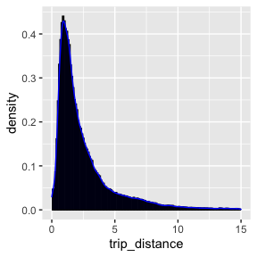

```r
ggplot(green, aes(x=trip_distance)) +
        geom_histogram(aes(y=..density..), binwidth=.1, colour="black", fill="white") +
        geom_density(alpha=.2, colour="blue", fill="#000066")+  xlim(0, 15)
```

# Classification

## Add `mean` and `median` of `trip_distance` grouped `hour` of pickup time

```r
st <- proc.time()
green$pickup_hour <- as.integer(format(strptime(green$lpep_pickup_datetime, "%Y-%m-%d %H:%M:%S"),"%H"))
hourly_trip_distance <- data.frame( green %>%
                                   group_by(pickup_hour) %>%
                                   summarise(mean_trip_dist = mean(trip_distance),
                                             median_trip_dist = median(trip_distance)) %>% ungroup())
head(hourly_trip_distance)
```

```
##   pickup_hour mean_trip_dist median_trip_dist
## 1           0       2.833005            1.850
## 2           1       2.848688            1.800
## 3           2       2.931595            1.810
## 4           3       3.302185            2.000
## 5           4       3.242655            2.025
## 6           5       4.333602            2.700
```

```r
print(proc.time() - st)
```

```
##    user  system elapsed
##   1.176   0.025   1.203
```

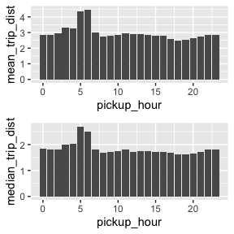

```r
# Mean trip distance plot
m.trip.dist.plt <- ggplot(hourly_trip_distance, aes(x=pickup_hour, y=mean_trip_dist)) + geom_bar(stat = "identity")
# Median trip distance plot
M.trip.dist.plt <- ggplot(hourly_trip_distance, aes(x=pickup_hour, y=median_trip_dist)) + geom_bar(stat = "identity")
grid.arrange(m.trip.dist.plt, M.trip.dist.plt, ncol=1, nrow =2)
```

From above, we conclude that the longest trips are at `5` & `6` in the morning. In rest of the day’s hours trips are somehow close in terms of distance traveled. //////////////////////////////////////////////////////////////////////////

## `tip_percentage` is the tip percentage based on `total_amount`

```r
st <- proc.time()
green$tip_percentage <- ifelse(green$tip_amount==0.0 | green$total_amount==0.0 , 0.0,
                        round(green$tip_amount/green$total_amount,3))
# Remove all zero percentage as they are not going to help us in classification
num.obs <- nrow(green)
green <- green[green$tip_percentage > 0,]
cat("[", num.obs-nrow(green), "] Observation have been deleted! Which is ~ (", round((num.obs-nrow(green))/num.obs, digits = 3), ")")
```

```
## [ 188251 ] Observation have been deleted! Which is ~ ( 0.537 )
```

```r
print(proc.time() - st)
```

```
##    user  system elapsed
##   0.122   0.024   0.146
```

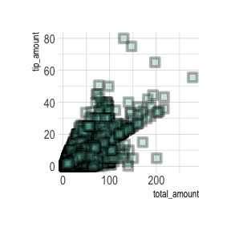

```r
ggplot(green, aes(x=total_amount, y=tip_amount)) +
    geom_point(
        color="black",
        fill="#69b3a2",
        shape=22,
        alpha=0.3,
        size=3,
        stroke =2
        ) +
    theme_ipsum()
```

`geom_point` is useful when we want to compare two continuous variables. //////////////////////////////////////////////////////////////////////////

```r
cat("Average tip percentage of the total amount ~ (",
    round((sum(green$tip_amount)/sum(green$total_amount)),4)*100 ," %)")
```

```
## Average tip percentage of the total amount ~ ( 15.59  %)
```

## Histogram of `tip_percentage`

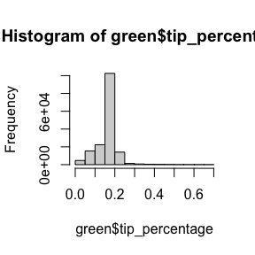

```r
hist(green$tip_percentage)
```

## Classification using Decision Tree ### Split data into training & testing

```r
sample.size <- floor(0.75*nrow(green))
s <- sample(seq_len(nrow(green)), sample.size)
numeic.cols <- green %>% select_if(is.numeric)
train.set <- numeic.cols[s,]
test.set <- numeic.cols[-s, ]
```

```r
dt.model <- rpartXse(tip_percentage ~ ., train.set, se = 0.5)
dt.predicted <- round(predict(dt.model, test.set), digits = 3)
saveRDS(file = "data/dt_model.rds", object = dt.model)
saveRDS(file = "data/dt_pred.rds", object = dt.predicted)
head(dt.predicted)
```

```
##    20    63    65    92    93   104
## 0.167 0.057 0.093 0.167 0.167 0.065
```

```r
print(proc.time() - st, paste("\n"))
```

```
##    user  system elapsed
##  22.025   0.269  22.372
```

## Load DT Model

```r
dt.model <- readRDS("data/dt_model.rds")
dt.predicted <- readRDS("data/dt_pred.rds")
```

```r
dt.perf.matrix <- as.data.frame(test.set$tip_percentage) %>% cbind(dt.predicted)
colnames(dt.perf.matrix) <- c("actual", "pred")
dt.perf.matrix["error"] <- dt.perf.matrix["actual"]-dt.perf.matrix["pred"]
dt.perf.matrix["error/actual"] <- abs(dt.perf.matrix["error"]/dt.perf.matrix["actual"])
head(dt.perf.matrix)
```

```
##     actual  pred error error/actual
## 20   0.167 0.167 0.000   0.00000000
## 63   0.059 0.057 0.002   0.03389831
## 65   0.093 0.093 0.000   0.00000000
## 92   0.167 0.167 0.000   0.00000000
## 93   0.167 0.167 0.000   0.00000000
## 104  0.066 0.065 0.001   0.01515152
```

## Measuring performance using Mean Absolute Percentage Error (MAPE)

```r
dt.mape <- mean(dt.perf.matrix$`error/actual`)
cat("Error percentage: (", round(dt.mape, 4), ") \nSuccess percentage: (", round(100-dt.mape, 4),")")
```

```
## Error percentage: ( 0.0048 )
## Success percentage: ( 99.9952 )
```

```r
dt.mse <- mse(test.set$tip_percentage, dt.predicted)
dt.mae <- mae(test.set$tip_percentage, dt.predicted)
dt.rmse <- rmse(test.set$tip_percentage, dt.predicted)
dt.r2 <- R2(test.set$tip_percentage, dt.predicted, form = "traditional")

cat(" MAE:", dt.mae, "\n", "MSE:", dt.mse, "\n",
    "RMSE:", dt.rmse, "\n", "R-squared:", dt.r2)
```

```
##  MAE: 0.0004403405
##  MSE: 8.424944e-06
##  RMSE: 0.002902575
##  R-squared: 0.9968075
```

As we can see from above, if we accept only 3 digits after the point, which may cause some lose in data thus error, we obtained a very good success rate using RT. ////////////////////////////////////////////////////////////////////////// ## Using Support Vector Machine (SVM)

```r
st <- proc.time()
svm.model <- svm(tip_percentage ~ ., train.set)
svm.predicted <- round(predict(svm.model, test.set), digits = 3)
saveRDS(object = svm.model, file = "data/svm_model.rds")
saveRDS(object = svm.predicted, file = "data/svm_pred.rds")
print(proc.time() - st)
```

```
##    user  system elapsed
## 174.749   0.700 175.792
```

## Load SVM Model

```r
svm.model <- readRDS("data/svm_model.rds")
svm.predicted <- readRDS("data/svm_pred.rds")
```

## Measuring performance using Mean Absolute Percentage Error (MAPE)

```r
svm.perf.matrix <- as.data.frame(test.set$tip_percentage) %>% cbind(svm.predicted)
colnames(svm.perf.matrix) <- c("actual", "pred")
svm.perf.matrix["error"] <- svm.perf.matrix["actual"]-svm.perf.matrix["pred"]
svm.perf.matrix["error/actual"] <- abs(svm.perf.matrix["error"]/svm.perf.matrix["actual"])
head(svm.perf.matrix)
```

```
##     actual  pred error error/actual
## 20   0.167 0.166 0.001  0.005988024
## 63   0.059 0.055 0.004  0.067796610
## 65   0.093 0.091 0.002  0.021505376
## 92   0.167 0.163 0.004  0.023952096
## 93   0.167 0.166 0.001  0.005988024
## 104  0.066 0.064 0.002  0.030303030
```

```r
svm.mape <- mean(svm.perf.matrix$`error/actual`)
cat("Error percentage: (", round(svm.mape, 4), ") \nSuccess percentage: (", round(100-svm.mape, 4),")")
```

```
## Error percentage: ( 0.0516 )
## Success percentage: ( 99.9484 )
```

```r
svm.mse <- mse(test.set$tip_percentage, svm.predicted)
svm.mae <- mae(test.set$tip_percentage, svm.predicted)
svm.rmse <- rmse(test.set$tip_percentage, svm.predicted)
svm.r2 <- R2(test.set$tip_percentage, svm.predicted, form = "traditional")

cat(" MAE:", svm.mae, "\n", "MSE:", svm.mse, "\n",
    "RMSE:", svm.rmse, "\n", "R-squared:", svm.r2)
```

```
##  MAE: 0.00232149
##  MSE: 3.388009e-05
##  RMSE: 0.005820661
##  R-squared: 0.9869203
```

## Using Neural Network

```r
st <- proc.time()
nn.model <- nnet(tip_percentage ~ ., train.set,
           linout=TRUE,
           trace=FALSE,
           size=6,
           decay=0.01,
           maxit=2000)
nn.pred <- predict(nn.model, test.set)
saveRDS(nn.model, "data/nn_model.rds")
saveRDS(nn.pred, "data/nn_pred.rds")
print(proc.time() - st)
```

```
##    user  system elapsed
##  31.972   0.184  32.276
```

## Load NN model

```r
nn.model <- readRDS("data/nn_model.rds")
nn.pred <- readRDS("data/nn_pred.rds")
```

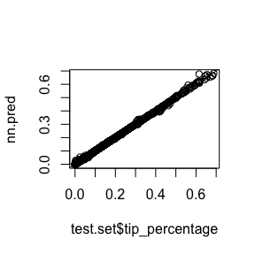

```r
plot(test.set$tip_percentage, nn.pred)
abline(0, 1)
```

From the plot above, we realize that when the `tip_percentage` is larger the errors, or the residuals become larger. ///////////////////////////////////////////////////////////////////////